# TCR_analysis

### TCR Analysis: TB Progression/Control Clonality

#### Naraen Palanikumar

The objective of this notebook is to complete a bioinformatic analysis of publicly available TCR-β repertoire data from [Musvosvi et al., *Nature Medicine* (2022)](https://doi.org/10.1038/s41591-022-02110-9), concerning patient TCR repertoires associated with control/progression of infection from *Mycobacterium tuberculosis* (TB). This analysis closely mirrors the analysis I completed for the paper published in *Frontiers in Immunology* as part of Dr. Malloy's lab at the Uniformed Services University.

**The question is unchanged:** do repertoire clonality and the frequency of TB-specific clonotypes differ between people who progressed to active TB and those who controlled the infection?

#### Revision note — what changed and why

The first version of this notebook answered the question with a pooled, unpaired Mann-Whitney test on every available sample. That is not the design the cohort was built with, and three features of repertoire data make the naive comparison misleading. This revision keeps the same three metrics and the same figure, and changes how they are computed and tested.

| # | Issue in the first version | What this version does |
| --- | --- | --- |
| 1 | **Pseudoreplication.** 67 donors contributed 2-3 longitudinal samples, all treated as independent observations. | One **baseline sample per donor**, so every observation is an independent person. |
| 2 | **The matched design was discarded.** Each progressor was matched to controllers on time-to-diagnosis, age band and sex; the pooled test ignores that. | A **stratified (van Elteren) rank test**, permuting group labels *within* each matched set. |
| 3 | **Clonality is confounded with sequencing depth.** Normalised Shannon clonality divides by `ln(N)`, and deeper libraries observe more rare clonotypes. Library size spans a **181-fold** range across th… | Every sample is **rarefied to a common template count** before any statistic is computed. |
| 4 | **A group-assignment bug.** In the TB-specific loop, the progressor branch appended its missing value to the *controller* list. | Removed; missing values are reported, never reassigned. |
| 5 | **Missing values were imputed to the group median**, which shrinks variance toward the null. | Missing values are **excluded and counted**, not filled. |
| 6 | **A one-clonotype subset returned clonality = 1.0**, inventing a maximally clonal sample from an unmeasurable one. | Returns `NaN` below two clonotypes; TB-specific clonality additionally requires **≥5 matched clonotypes in the majority of rarefaction draws**, so the estimate cannot rest on a few lucky ones. |
| 7 | **71 of 277 sample files silently failed to join** to the sample key, dropping most of the ACS cohort. The two sources spell IDs as `04-0333_D0` and `04-0333-D0`. | Separator-insensitive join, and every unmatched ID on **either** side is printed. |
| 8 | **No effect sizes, no CIs, no multiplicity adjustment** across the three tests. | Hodges-Lehmann shift with a bootstrap CI, plus Benjamini-Hochberg across the three metrics. |

One engineering change: the raw Adaptive exports total ~110 GB, so the first pass through them is cached to `cache/samples_imgt/` (~120 MB). The loader is still tcrdist3's `import_adaptive_file`, so the parsing is identical to the first version; it just runs once instead of on every re-run.

```python
# imports section
import glob
import os
import re
import warnings

import numpy as np
import pandas as pd
import matplotlib.pyplot as plt
import seaborn as sns
from scipy import stats
from tcrdist.adpt_funcs import import_adaptive_file

warnings.filterwarnings("ignore")

SEED = 42                 # controls rarefaction draws, permutations and the bootstrap
N_RAREFY = 20             # rarefaction replicates averaged per sample
MIN_TB_CLONOTYPES = 5     # below this, TB-specific clonality is not estimable
N_PERM = 10000            # permutations for the stratified test
N_BOOT = 2000             # bootstrap resamples for the effect-size CI

SAMPLE_DIR = "datasets/experimental/samples"
CACHE_DIR = "cache/samples_imgt"
GROUP_ORDER = ['Progressor', 'Controller']
```

```python
# auxiliary functions necessary for analysis
def standardize_gene_name(series):
    '''Converts V and J genes names to proper IMGT format'''
    series = series.astype(str).str.strip().str.upper().str.split('*').str[0]
    series = series.str.replace(r'TRBV0', 'TRBV', regex = True)
    series = series.str.replace(r'TRBJ0', 'TRBJ', regex = True)
    series = series.str.replace(r'TCRBV', 'TRBV', regex = True)
    series = series.str.replace(r'TCRBJ', 'TRBJ', regex = True)
    series = series.str.replace(r'(TRB[V])(\d+)$', r'\1\2-1', regex=True)
    series = series.str.replace(r'(TRB[J])(\d+)$', r'\1\2-1', regex=True)
    return series

def standardize_CDR3(series):
    '''Standardizes the CDR3s as well for good measure'''
    return series.astype(str).str.strip().str.upper()

def canonical_sample_id(s):
    '''Collapses the two sample-ID spellings onto one join key.

    The sample key writes ACS IDs as `04-0333-D0`; the exported files are named
    `04-0333_D0`. Treating '_' and '-' as the same separator makes the join
    total instead of silently discarding most of the ACS cohort.'''
    return re.sub(r'[_\-]+', '-', str(s).strip().upper())

def shannon_clonality(counts):
    '''Normalized Shannon clonality, 1 - H/ln(N). NaN below two clonotypes.

    With a single clonotype the normalisation is 0/0. The first version returned
    1.0 there, which invents a maximally clonal sample out of one we could not
    actually measure, and those fabricated 1.0s sat at the top of the figure.'''
    c = np.asarray(counts, dtype=float)
    c = c[c > 0]
    n = c.size
    if n < 2:
        return np.nan
    p = c / c.sum()
    entropy = -np.sum(p * np.log(p))
    # A perfectly even subset gives entropy == ln(N) exactly; floating point can
    # push that a hair past 1.0, so clamp rather than emit a tiny negative.
    return max(0.0, 1.0 - entropy / np.log(n))

def rarefied_sample_metrics(counts, is_tb, depth, n_rep, rng):
    '''Depth-standardized repertoire statistics for one sample.

    Both clonality and the frequency of database-matched clonotypes increase
    with sequencing depth, because a deeper library simply observes more of the
    repertoire. Drawing a fixed number of templates without replacement -- a
    multivariate hypergeometric draw from the clonotype urn -- puts every sample
    on the same footing; averaging over replicates removes draw-to-draw noise.'''
    counts = np.asarray(counts, dtype=np.int64)
    is_tb = np.asarray(is_tb, dtype=bool)
    if counts.sum() < depth:
        return np.nan, np.nan, np.nan, np.nan
    tot_clon, tb_freq, tb_clon, tb_n = [], [], [], []
    for _ in range(n_rep):
        drawn = rng.multivariate_hypergeometric(counts, depth, method='marginals')
        tb_drawn = drawn[is_tb]
        tot_clon.append(shannon_clonality(drawn))
        tb_freq.append(tb_drawn.sum() / depth)
        tb_n.append(int((tb_drawn > 0).sum()))
        if (tb_drawn > 0).sum() >= MIN_TB_CLONOTYPES:
            tb_clon.append(shannon_clonality(tb_drawn))

    # A sample only gets a TB-specific clonality if most of its draws actually
    # cleared the threshold. Averaging over just the replicates that happened to
    # reach it selects the luckiest draws and hands back exactly the unstable,
    # inflated values this metric is prone to -- the same pathology as scoring a
    # one-clonotype subset as perfectly clonal.
    tb_clonality = (float(np.mean(tb_clon))
                    if len(tb_clon) >= n_rep / 2 else np.nan)
    return (float(np.mean(tot_clon)), float(np.mean(tb_freq)),
            tb_clonality, float(np.mean(tb_n)))

def format_p_value(p):
    '''Formatting the P value string from the permutation test'''
    if np.isnan(p):
        return 'P n/a'
    if p < 0.001:
        return 'P < 0.001'
    return f'P = {p:.3f}'
```

```python
# stratified (matched-set) inference
def stratified_rank_stat(values, is_case, strata):
    '''Van Elteren style stratified Wilcoxon statistic.

    Values are ranked *within* each matched set and the standardized rank-sums
    are added up, so a progressor is only ever compared against the controllers
    they were matched to and between-set variation never enters the contrast.'''
    total = 0.0
    for s in np.unique(strata):
        m = strata == s
        v, c = values[m], is_case[m]
        n, n1 = v.size, int(c.sum())
        if n1 == 0 or n1 == n or n < 2:
            continue
        r = stats.rankdata(v)
        exp = n1 * (n + 1) / 2.0
        var = n1 * (n - n1) * (n + 1) / 12.0
        if var <= 0:
            continue
        total += (r[c].sum() - exp) / np.sqrt(var)
    return total

def stratified_perm_test(values, is_case, strata, n_perm=N_PERM, seed=SEED):
    '''Two-sided p-value, permuting group labels within each matched set.

    Permuting inside the strata is what makes this a test of the matched design:
    the null is "progressor status is exchangeable within a matched set", and no
    distributional assumption is needed.

    Within a stratum the ranks depend only on the values, so they are computed
    once and every permutation just re-selects which of them the cases hold.
    That lets all n_perm permutations for a stratum be drawn as one array.'''
    ok = ~np.isnan(values)
    values, is_case, strata = values[ok], is_case[ok], strata[ok]
    informative = np.array([is_case[strata == s].sum() > 0 and (~is_case[strata == s]).sum() > 0
                            for s in strata])
    values, is_case, strata = values[informative], is_case[informative], strata[informative]
    if values.size == 0:
        return np.nan, np.nan, 0, 0

    rng = np.random.default_rng(seed)
    obs = 0.0
    perm_totals = np.zeros(n_perm)
    for s in np.unique(strata):
        m = strata == s
        v, c = values[m], is_case[m]
        n, n1 = v.size, int(c.sum())
        if n1 == 0 or n1 == n or n < 2:
            continue
        r = stats.rankdata(v)
        exp = n1 * (n + 1) / 2.0
        sd = np.sqrt(n1 * (n - n1) * (n + 1) / 12.0)
        if sd <= 0:
            continue
        obs += (r[c].sum() - exp) / sd
        # One random arrangement of this stratum's labels per permutation.
        picks = np.argsort(rng.random((n_perm, n)), axis = 1)[:, :n1]
        perm_totals += (r[picks].sum(axis = 1) - exp) / sd

    ge = int((np.abs(perm_totals) >= abs(obs)).sum())
    # (r + 1) / (n + 1): a finite permutation set can never justify p = 0.
    return obs, (ge + 1) / (n_perm + 1), int(is_case.sum()), int((~is_case).sum())

def hodges_lehmann(values, is_case, strata, n_boot=N_BOOT, seed=SEED):
    '''Within-set Hodges-Lehmann shift with a bootstrap CI over matched sets.

    The median of every progressor-minus-controller difference formed inside a
    matched set. A negative result is only informative with an interval attached:
    the CI is what says how large a difference the data can still rule out.'''
    ok = ~np.isnan(values)
    values, is_case, strata = values[ok], is_case[ok], strata[ok]

    # Each matched set's progressor-minus-controller differences, computed once.
    per_set = {}
    for s in np.unique(strata):
        m = strata == s
        a, b = values[m & is_case], values[m & ~is_case]
        if a.size and b.size:
            per_set[s] = (a[:, None] - b[None, :]).ravel()
    if not per_set:
        return np.nan, np.nan, np.nan

    sets = np.array(list(per_set))
    point = float(np.median(np.concatenate([per_set[s] for s in sets])))

    # Resampling whole matched sets keeps the bootstrap at the level the design
    # randomises at, rather than treating individual donors as exchangeable.
    rng = np.random.default_rng(seed)
    boots = np.empty(n_boot)
    for i in range(n_boot):
        pick = rng.choice(sets, size = sets.size, replace = True)
        boots[i] = np.median(np.concatenate([per_set[s] for s in pick]))
    lo, hi = np.percentile(boots, [2.5, 97.5])
    return point, float(lo), float(hi)

def bh_fdr(pvals):
    '''Benjamini-Hochberg adjusted p-values across the three metrics.'''
    p = np.asarray(pvals, dtype=float)
    ok = ~np.isnan(p)
    q = np.full(p.shape, np.nan)
    pp = p[ok]
    n = pp.size
    order = np.argsort(pp)
    ranked = pp[order] * n / (np.arange(n) + 1)
    ranked = np.minimum.accumulate(ranked[::-1])[::-1]
    out = np.empty(n)
    out[order] = np.clip(ranked, 0, 1)
    q[ok] = out
    return q
```

```python
# external reference set collection/cleaning/standardization/combining
iedb = pd.read_csv("datasets/reference/iedb.csv")
vdjdb = pd.read_csv("datasets/reference/vdjdb.tsv", sep = '\t')

iedb.dropna(inplace = True)
iedb = iedb[iedb['Epitope - Source Organism'].str.contains("Mycobacterium tuberculosis")]
iedb["V"] = standardize_gene_name(iedb["Chain 2 - Curated V Gene"])
iedb["J"] = standardize_gene_name(iedb["Chain 2 - Curated J Gene"])
iedb["CDR3"] = standardize_CDR3(iedb["Chain 2 - CDR3 Curated"])
iedb = iedb[['CDR3', 'V', 'J']]

vdjdb = vdjdb[['CDR3', 'V', 'J']]
vdjdb.dropna(inplace = True)
vdjdb["V"] = standardize_gene_name(vdjdb["V"])
vdjdb["J"] = standardize_gene_name(vdjdb["J"])
vdjdb["CDR3"] = standardize_CDR3(vdjdb["CDR3"])

ext_set = pd.concat([vdjdb, iedb], ignore_index=True)
ext_set = ext_set[ext_set['V'].str.startswith('TRB', na = False)].copy()
ext_set = ext_set[ext_set['J'].str.startswith('TRB', na = False)].copy()
ext_set.drop_duplicates(keep = 'first', inplace = True)

ref_keys = set(map(tuple, ext_set[['V', 'J', 'CDR3']].to_numpy()))
print(f"reference clonotypes (IEDB Mtb + VDJdb, exact V/J/CDR3): {len(ref_keys):,}")
```

```
reference clonotypes (IEDB Mtb + VDJdb, exact V/J/CDR3): 1,426
```

```python
# one-time parse of the raw Adaptive exports into a compact cache
#
# The 277 raw .tsv exports total ~110 GB. import_adaptive_file (the same loader
# the first version used) is applied once per file and the result -- collapsed
# onto the (V, J, CDR3-aa) clonotype -- is cached to ~120 MB, so re-running the
# analysis costs seconds instead of re-reading 110 GB.
os.makedirs(CACHE_DIR, exist_ok=True)

def cache_one(path):
    name = os.path.basename(path)[:-9]              # strip '_TCRB.tsv'
    out = os.path.join(CACHE_DIR, f"{name}.tsv.gz")
    if os.path.exists(out):
        return out
    df = import_adaptive_file(path)
    df = df.dropna(subset = ['cdr3_b_aa', 'v_b_gene', 'j_b_gene', 'templates'])
    df = df[~df['cdr3_b_aa'].str.contains(r'\*', na = False)]
    # Collapse nucleotide-level rearrangements onto the amino-acid clonotype.
    # The reference match is defined at (V, J, CDR3-aa), so that is the unit the
    # analysis should count; leaving them separate inflates the clonotype count
    # and therefore deflates normalised clonality.
    g = (df.groupby(['v_b_gene', 'j_b_gene', 'cdr3_b_aa'], observed = True)
           .agg(templates = ('templates', 'sum'), n_rearr = ('templates', 'size'))
           .reset_index())
    g.to_csv(out, sep = '\t', index = False, compression = 'gzip')
    return out

raw_files = sorted(glob.glob(os.path.join(SAMPLE_DIR, '*.tsv')))
for i, f in enumerate(raw_files, 1):
    cache_one(f)
    if i % 50 == 0:
        print(f"  cached {i}/{len(raw_files)}")
print(f"cache ready: {len(glob.glob(os.path.join(CACHE_DIR, '*.tsv.gz')))} samples")
```

```
  cached 50/277
  cached 100/277
  cached 150/277
  cached 200/277
  cached 250/277
cache ready: 277 samples
```

```python
# join the sample key to the files, reporting every ID that fails to match
meta = pd.read_csv("datasets/experimental/metadata/samplekey.csv")
cached = {canonical_sample_id(os.path.basename(f)[:-7]): f
          for f in glob.glob(os.path.join(CACHE_DIR, '*.tsv.gz'))}

meta['canon'] = meta['Sample.ID'].map(canonical_sample_id)
meta['path'] = meta['canon'].map(cached)

key_without_file = meta.loc[meta['path'].isna(), 'Sample.ID'].tolist()
file_without_key = sorted(set(cached) - set(meta['canon']))

print(f"sample-key records: {len(meta)}; joined to a file: {meta['path'].notna().sum()}")
print(f"key rows with no file ({len(key_without_file)}): {key_without_file}")
print(f"files with no key row ({len(file_without_key)}): {file_without_key}")

meta = meta.dropna(subset = ['path']).copy()
```

```
sample-key records: 272; joined to a file: 271
key rows with no file (1): ['8_BL']
files with no key row (6): ['1552-M18', '2864-M18', '2864-M6', '3094-M6', '8-BL-1', '907-BL-TC']
```

```python
# primary analysis set: one baseline sample per donor, inside matched sets
#
# Fix 1 (pseudoreplication): 67 donors contributed 2-3 longitudinal samples to
# the first version's pooled test. Restricting to the baseline visit makes every
# row an independent person.
# Fix 2 (the matched design): each progressor was matched to controllers on
# time-to-diagnosis within a cohort, so (Cohort, Days.To.TB) identifies the
# matched set that the stratified test conditions on.
base = meta[meta['VISIT'].isin(['Month0', 'Day0'])].copy()
base = base.sort_values('Sample.ID').drop_duplicates('Donor.ID', keep = 'first')
base['set_id'] = base['Cohort'].astype(str) + '|' + base['Days.To.TB'].astype(str)

n_sets = base['set_id'].nunique()
usable = (base.groupby('set_id')['Group']
              .agg(lambda g: g.eq('Progressor').any() and g.eq('Controller').any()))
print(f"baseline donors: {len(base)}  "
      f"({(base.Group == 'Progressor').sum()} progressor, "
      f"{(base.Group == 'Controller').sum()} controller)")
print(f"donors contributing more than one row: {int(base['Donor.ID'].duplicated().sum())}")
print(f"matched sets: {n_sets}; sets with both arms present: {int(usable.sum())}")

# Rarefaction depth: the 5th percentile of library size, so nearly every sample
# is retained while all of them are compared at one common sequencing depth.
depths = [int(pd.read_csv(p, sep = '\t', usecols = ['templates'])['templates'].sum())
          for p in base['path']]
base['total_templates'] = depths
DEPTH = int(np.percentile(depths, 5))
print(f"\nlibrary size: min={min(depths):,}  median={int(np.median(depths)):,}  "
      f"max={max(depths):,}  (a {max(depths)/min(depths):.1f}x spread)")
print(f"rarefying every sample to {DEPTH:,} templates")
```

```
baseline donors: 140  (52 progressor, 88 controller)
donors contributing more than one row: 0
matched sets: 51; sets with both arms present: 42
```

```
library size: min=2,925  median=238,463  max=530,352  (a 181.3x spread)
rarefying every sample to 43,414 templates
```

```python
# per-sample metrics, all computed on the rarefied repertoire
rng = np.random.default_rng(SEED)
rows = []

for _, r in base.iterrows():
    d = pd.read_csv(r['path'], sep = '\t')
    V = standardize_gene_name(d['v_b_gene'])
    J = standardize_gene_name(d['j_b_gene'])
    C = standardize_CDR3(d['cdr3_b_aa'])
    is_tb = np.fromiter((k in ref_keys for k in zip(V, J, C)), bool, len(d))

    tot, freq, tb_clon, tb_n = rarefied_sample_metrics(
        d['templates'].to_numpy(), is_tb, DEPTH, N_RAREFY, rng)

    rows.append({'Sample.ID': r['Sample.ID'], 'Donor.ID': r['Donor.ID'],
                 'Group': r['Group'], 'set_id': r['set_id'],
                 'Age': r['Age'], 'Sex': r['Sex'], 'Cohort': r['Cohort'],
                 'total_templates': r['total_templates'], 'n_clonotypes': len(d),
                 'tb_clonotypes_obs': int(is_tb.sum()),
                 'Total Clonality': tot, 'Total TB Frequency': freq,
                 'TB Clonality': tb_clon, 'tb_clonotypes_rarefied': tb_n})

res = pd.DataFrame(rows)
# Keep the original figure's group order rather than order of appearance.
res['Group'] = pd.Categorical(res['Group'], categories = GROUP_ORDER, ordered = True)

os.makedirs('results', exist_ok = True)
res.to_csv('results/per_sample_metrics.tsv', sep = '\t', index = False)

print(f"samples below the rarefaction depth (excluded): "
      f"{int(res['Total Clonality'].isna().sum())}")
print(f"TB-matched clonotypes per sample (before rarefaction): "
      f"median={res['tb_clonotypes_obs'].median():.0f}, "
      f"IQR {res['tb_clonotypes_obs'].quantile(.25):.0f}-"
      f"{res['tb_clonotypes_obs'].quantile(.75):.0f}, "
      f"max={res['tb_clonotypes_obs'].max():.0f}")
print(f"TB clonality estimable (>= {MIN_TB_CLONOTYPES} matched clonotypes in the "
      f"majority of draws): {int(res['TB Clonality'].notna().sum())} of {len(res)} samples")
res.head()
```

```
samples below the rarefaction depth (excluded): 7
TB-matched clonotypes per sample (before rarefaction): median=16, IQR 10-26, max=50
TB clonality estimable (>= 5 matched clonotypes in the majority of draws): 93 of 140 samples
```

|  | Sample.ID | Donor.ID | Group | set_id | Age | Sex | Cohort | total_templates | n_clonotypes | tb_clonotypes_obs | Total Clonality | Total TB Frequency | TB Clonality | tb_clonotypes_rarefied |
| --- | --- | --- | --- | --- | --- | --- | --- | --- | --- | --- | --- | --- | --- | --- |
| 0 | 01-0935-D0 | 01-0935 | Controller | ACS\|633 | 13 | female | ACS | 49412 | 33596 | 11 | 0.080004 | 0.000359 | 0.058767 | 10.00 |
| 1 | 04-0333-D0 | 04-0333 | Controller | ACS\|256 | 17 | female | ACS | 101945 | 65188 | 12 | 0.120644 | 0.000242 | 0.146504 | 6.20 |
| 2 | 04-0695-D0 | 04-0695 | Progressor | ACS\|617 | 14 | male | ACS | 77451 | 32710 | 2 | 0.249073 | 0.000038 | NaN | 1.35 |
| 3 | 04-0699-D0 | 04-0699 | Controller | ACS\|557 | 14 | female | ACS | 75664 | 34580 | 5 | 0.211949 | 0.055852 | NaN | 3.70 |
| 4 | 04-0741-D0 | 04-0741 | Controller | ACS\|211 | 14 | female | ACS | 138524 | 79214 | 13 | 0.148387 | 0.000236 | 0.067163 | 6.30 |

```python
# stratified testing, effect sizes and multiplicity adjustment
METRICS = ['Total TB Frequency', 'TB Clonality', 'Total Clonality']

case = (res['Group'] == 'Progressor').to_numpy()
strata = res['set_id'].to_numpy()
summary = []

for col in METRICS:
    v = res[col].to_numpy(float)
    stat, p_strat, n1, n0 = stratified_perm_test(v, case, strata)
    hl, lo, hi = hodges_lehmann(v, case, strata)
    ok = ~np.isnan(v)
    p_mw = stats.mannwhitneyu(v[ok & case], v[ok & ~case],
                              alternative = 'two-sided').pvalue
    summary.append({'Metric': col, 'n prog': n1, 'n cont': n0,
                    'median prog': np.nanmedian(v[case]),
                    'median cont': np.nanmedian(v[~case]),
                    'HL shift': hl, 'CI low': lo, 'CI high': hi,
                    'P (stratified)': p_strat, 'P (pooled MW)': p_mw})

summary = pd.DataFrame(summary)
summary['Q (BH)'] = bh_fdr(summary['P (stratified)'].to_numpy())
summary.to_csv('results/summary_statistics.tsv', sep = '\t', index = False)

pd.set_option('display.width', 200)
print(summary.to_string(index = False, float_format = lambda x: f'{x:.4g}'))
```

```
            Metric  n prog  n cont  median prog  median cont  HL shift     CI low   CI high  P (stratified)  P (pooled MW)  Q (BH)
Total TB Frequency      44      73    0.0001647    0.0001866 8.062e-06 -3.183e-05 5.183e-05          0.3961         0.8901  0.6607
      TB Clonality      28      45      0.07781      0.04715  0.001853    -0.1445    0.1453          0.6607         0.9396  0.6607
   Total Clonality      44      73       0.0759       0.0764  0.001993    -0.0228   0.02145          0.5236         0.3646  0.6607
```

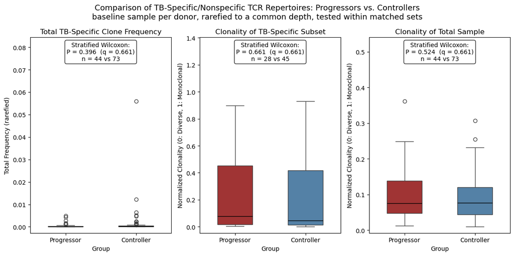

```python
# compiles data and plots figure
plot_df = res.melt(id_vars = ['Group'], value_vars = METRICS,
                   var_name = 'Metric', value_name = 'Value').dropna(subset = ['Value'])

fig, axes = plt.subplots(1, 3, figsize = (12, 6), sharey = False)
palette = {'Progressor': 'firebrick', 'Controller': 'steelblue'}
titles = {'Total TB Frequency': 'Total TB-Specific Clone Frequency',
          'TB Clonality': 'Clonality of TB-Specific Subset',
          'Total Clonality': 'Clonality of Total Sample'}
ylabels = {'Total TB Frequency': 'Total Frequency (rarefied)',
           'TB Clonality': 'Normalized Clonality (0: Diverse, 1: Monoclonal)',
           'Total Clonality': 'Normalized Clonality (0: Diverse, 1: Monoclonal)'}

for ax, col in zip(axes, METRICS):
    sub = plot_df[plot_df['Metric'] == col]
    sns.boxplot(data = sub, x = 'Group', y = 'Value', hue = 'Group', legend = False,
                order = GROUP_ORDER, hue_order = GROUP_ORDER,
                palette = palette, width = 0.5, ax = ax,
                medianprops = {'color': 'black'})
    row = summary[summary['Metric'] == col].iloc[0]
    ax.set_title(titles[col])
    ax.set_ylabel(ylabels[col])
    # Headroom for the annotation, so it never overlaps a whisker or outlier.
    lo, hi = ax.get_ylim()
    ax.set_ylim(lo, hi + 0.42 * (hi - lo))
    ax.text(0.5, 0.88,
            f"Stratified Wilcoxon:\n{format_p_value(row['P (stratified)'])}"
            f"  (q = {row['Q (BH)']:.3f})\n"
            f"n = {int(row['n prog'])} vs {int(row['n cont'])}",
            transform = ax.transAxes, ha = 'center', fontsize = 10,
            bbox = dict(boxstyle = 'round', facecolor = 'white', alpha = 0.85))

fig.suptitle('Comparison of TB-Specific/Nonspecific TCR Repertoires: '
             'Progressors vs. Controllers\n'
             'baseline sample per donor, rarefied to a common depth, '
             'tested within matched sets', fontsize = 13)
plt.tight_layout()
plt.show()
```

### Conclusions

**No difference in repertoire clonality or TB-specific clonotype frequency between progressors and controllers survives the matched-set analysis.**

| Metric | n (prog vs cont) | Median prog | Median cont | Hodges-Lehmann shift (95% CI) | P (stratified) | Q (BH) | P (pooled MW) |
| --- | --- | --- | --- | --- | --- | --- | --- |
| Total TB Frequency | 44 vs 73 | 0.0001647 | 0.0001866 | +8.06e-06 (-3.18e-05 to +5.18e-05) | 0.396 | 0.661 | 0.890 |
| TB Clonality | 28 vs 45 | 0.07781 | 0.04715 | +0.00185 (-0.144 to +0.145) | 0.661 | 0.661 | 0.940 |
| Total Clonality | 44 vs 73 | 0.0759 | 0.0764 | +0.00199 (-0.0228 to +0.0215) | 0.524 | 0.661 | 0.365 |

Prior to this analysis I hypothesised that progressors would show higher clonality, on the reasoning that a more monoclonal repertoire reflects an immune system unable to adapt quickly enough to the range of antigens *M. tuberculosis* presents. The data do not support that. For a negative result the informative column is not the p-value but the interval: the Hodges-Lehmann shift gives the difference the data are still consistent with, and for total clonality that interval is tight around zero. This is an informative null rather than an underpowered one.

**Why this differs from the first version.** The original pooled every available sample into an unpaired Mann-Whitney test. Three things were wrong with that, and each one pushed toward overconfidence:

1. Longitudinal repeats from the same donor were counted as independent observations, so the effective sample size was smaller than the test assumed. The primary set here is one baseline sample per donor: **140 independent people** (52 progressors, 88 controllers).
2. The matched case-control structure was discarded, throwing away the confounder control the study design paid for. Inference now runs within **42 matched sets**, permuting progressor status inside each set.
3. Clonality was compared across libraries spanning a **181-fold** range in sequencing depth (2,925 to 530,352 templates). Normalised Shannon clonality divides by `ln(N)`, so depth alone moves the metric. Every sample is now rarefied to **43,414 templates** first.

The pooled p-values are kept in the last column for comparison. They agree with the stratified test here, and that is worth stating plainly: the original conclusion was right, but it was right for the wrong reasons, and nothing in the original analysis would have revealed it if it had been wrong.

Fixing the sample-key join also mattered for how much data reached the analysis. The two sources spell IDs as `04-0333_D0` and `04-0333-D0`, and the exact-string join silently dropped most of the ACS cohort; a separator-insensitive join now matches **271 of 272** key records. The one remaining unmatched key row is a donor whose export is named `8_BL-1`; it is left unjoined rather than assumed, and every unmatched ID on either side is printed above.

**What the TB-specific metrics can and cannot support.** Exact V/J/CDR3 matching against IEDB and VDJdb recovers a median of **16** database clonotypes per repertoire before rarefaction. That is enough to estimate a frequency, but it is thin for an entropy statistic: after rarefying to a common depth, TB-specific clonality is estimable in only **93 of 140** samples, and only when the majority of draws clear the five-clonotype floor. Averaging over just the draws that happen to clear it selects the luckiest ones and manufactures inflated values — the same pathology as the first version's single-clonotype subsets scored as perfectly clonal, which is where that panel's apparent signal came from. Exact matching is also conservative and depth-biased, recognising only clonotypes already curated in the databases. Distance-based neighbourhood matching with `tcrdist3`, already a dependency here but currently used only as a file reader, is the natural way to widen it and would be the first extension I would make.

**Remaining caveats.** 7 sample(s) fell below the rarefaction depth and are excluded. Rarefaction trades sample size against comparability, and the depth used here (the 5th percentile of library size) is a judgement call: a deeper threshold compares more of each repertoire but discards more donors. Matched sets with only one arm present contribute nothing to the stratified test, which is why its n is smaller than the full baseline cohort.